# Review3 - Exploratory Data Analysis on Zomato Restaurants present in India

## Restaurant chains in Chennai

```r
df1=df1%>%
  select(-timings)

eo=df1%>%
  select(-delivery,-cuisines,-highlights)

eo=unique(eo)

eo=eo%>%
  select(name)%>%
  group_by(name)%>%
  summarise(count=n())
```

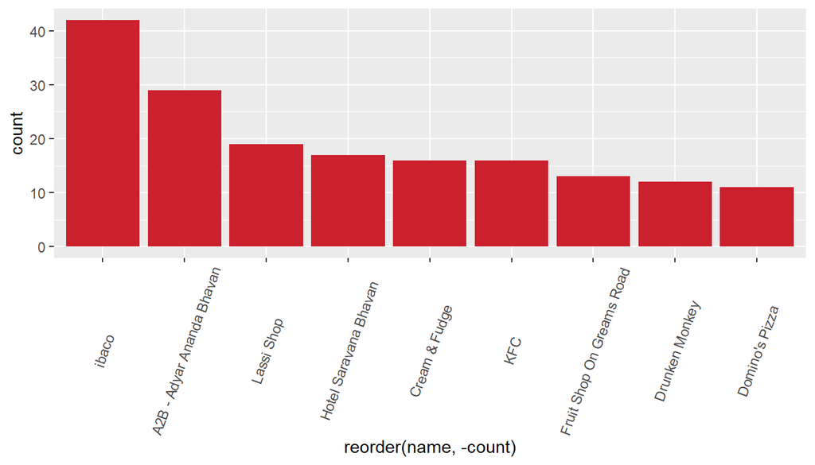

```r
chains=eo%>%
  filter(count>10)

ggplot(chains,aes(x=reorder(name,-count),y=count))+geom_bar(stat='identity',fill='#cb202d')+theme(axis.text.x = element_text(angle = 70, vjust = .5))
```

#### **INFERENCE:** Ibaco has the largest restaurant chain in Chennai followed by A2B,lassi Shop,Saravan Bhavan and so on.

### Restaurants with small chains around Chennai

```r
chainsmall=eo%>%
  filter(count>5 &count<9)
chainsmall
```

```
## # A tibble: 19 x 2
##    name                      count
##    <chr>                     <int>
##  1 AB's - Absolute Barbecues     6
##  2 Barbeque Nation               8
##  3 Behrouz Biryani               8
##  4 Cake Square                   6
##  5 CK's Bakery                   6
##  6 Copper Kitchen                6
##  7 Cream Stone                   7
##  8 Dindigul Thalappakatti        6
##  9 Hot Chips                     6
## 10 Keventers                     7
## 11 Madras Coffee House           8
## 12 Makers of Milkshakes          6
## 13 McDonald's                    7
## 14 Ovenfresh                     6
## 15 Subway                        7
## 16 The French Loaf               8
## 17 The ThickShake Factory        8
## 18 Tibbs Frankie                 6
## 19 Zaitoon                       6
```

### Quality of KFC in different localities of chennai based on aggregate ratings

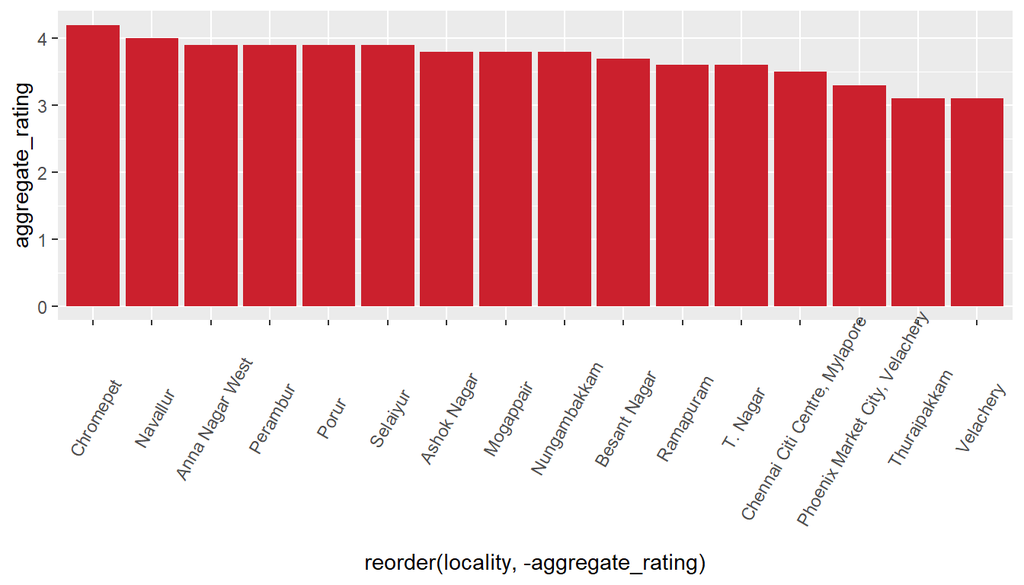

```r
c=df1%>%
  select(-delivery,-cuisines,-highlights)%>%
  filter(name=="KFC")

c=unique(c)

ggplot(c,aes(x=reorder(locality,-aggregate_rating),y=aggregate_rating))+geom_bar(stat='identity',fill='#cb202d')+theme(axis.text.x = element_text(angle = 60, vjust = .6))
```

#### **INFERENCE**:Quality of KFC is very good in Chrompet locality.Followed by Navallur,Anna nagar West and so on.

### Quality of A2B in different localities of chennai based on aggregate ratings

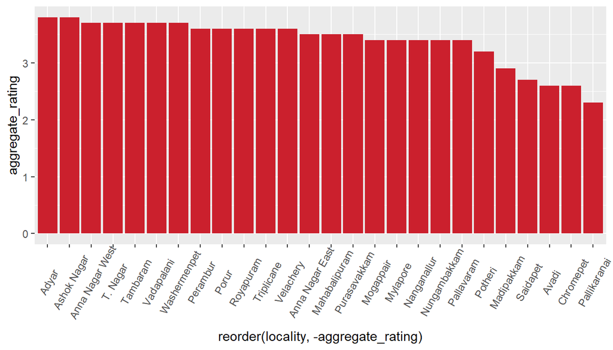

```r
d=df1%>%
  select(-delivery,-cuisines,-highlights)%>%
  filter(name=="A2B - Adyar Ananda Bhavan")


d=unique(d)
d=d[c(-3,-18,-27),]


ggplot(d,aes(x=reorder(locality,-aggregate_rating),y=aggregate_rating))+geom_bar(stat='identity',fill='#cb202d')+theme(axis.text.x = element_text(angle = 60, vjust = .6))
```

#### **INFERENCE**:Quality of A2B is good in Adyar locality.Followed by Ashok Nagar,Anna nagar West and so on.

### Quality of Saravana Bhavan in different localities of chennai based on aggregate ratings

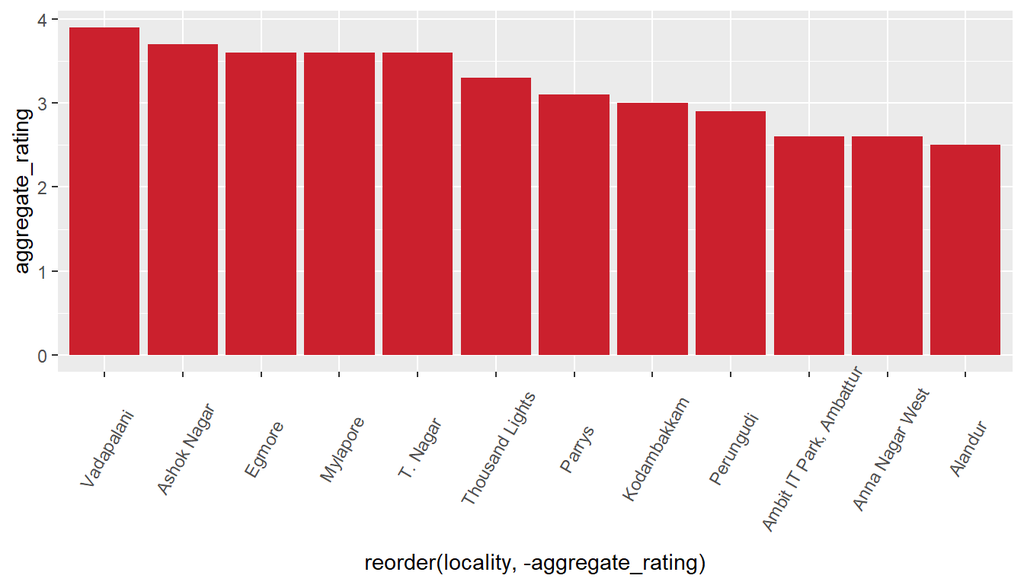

```r
e=df1%>%
  select(-delivery,-cuisines,-highlights)%>%
  filter(name=="Hotel Saravana Bhavan")
e=unique(e)
e=e[c(-5,-7,-9,-12,-17)]

e[10,4]="Thousand Lights"

ggplot(e,aes(x=reorder(locality,-aggregate_rating),y=aggregate_rating))+geom_bar(stat='identity',fill='#cb202d')+theme(axis.text.x = element_text(angle = 60, vjust = .6))
```

#### **INFERENCE**:Quality of Saravana Bhavan is very good in Vadapalani locality.Followed by Ashok Nagar,Egmore and so on.

## Restaurant chains in Mumbai

```r
df3=df%>%
  filter(city=="Mumbai")

df3=df3%>%
  select(-timings)

eo=df3%>%
  select(-delivery,-cuisines,-highlights)

eo=unique(eo)

eo=eo%>%
  select(name)%>%
  group_by(name)%>%
  summarise(count=n())
chains=eo%>%
  filter(count>10)
chains
```

```
## # A tibble: 16 x 2
##    name              count
##    <chr>             <int>
##  1 Behrouz Biryani      12
##  2 Burger King          11
##  3 Cafe Coffee Day      12
##  4 Celejor              14
##  5 Ek Cutting           23
##  6 Frozen Bottle        16
##  7 Keventers            23
##  8 KFC                  13
##  9 McDonald's           12
## 10 Natural Ice Cream    18
## 11 Subway               15
## 12 Sweet Bengal         12
## 13 Tea Villa Cafe       12
## 14 The J                17
## 15 The London Shakes    12
## 16 Theobroma            13
```

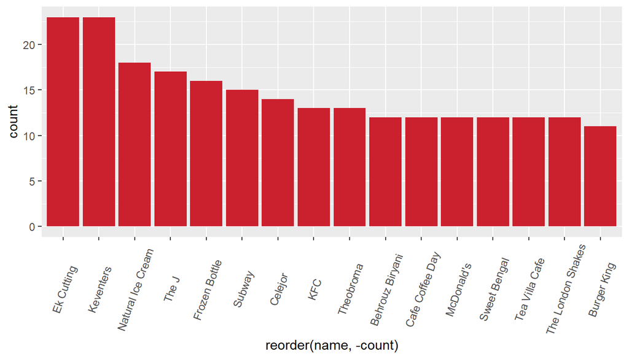

```r
ggplot(chains,aes(x=reorder(name,-count),y=count))+geom_bar(stat='identity',fill='#cb202d')+theme(axis.text.x = element_text(angle = 70, vjust = .5))
```

#### **INFERENCE**: Cafes like “Keventers”,“Ek cutting” has the largest restaurant chain in Mumbai followed by dessert parlours and fast food restaurants like Subway and KFC.

### Restaurants with small chains around Mumbai

```r
chainsmall=eo%>%
  filter(count>5 &count<9)
chainsmall
```

```
## # A tibble: 13 x 2
##    name                  count
##    <chr>                 <int>
##  1 Barbeque Nation           7
##  2 Bayroute                  7
##  3 BusaGo                    7
##  4 Charcoal Eats             6
##  5 Charcoal Eats Express     7
##  6 Coffee By Di Bella        8
##  7 Domino's Pizza            7
##  8 Indigo Delicatessen       6
##  9 Jughead's                 6
## 10 Mad Over Donuts           7
## 11 Merwans Cake Stop         7
## 12 The Beer Cafe             7
## 13 The Irish House           7
```

### Quality of KFC in different localities of Mumbai based on aggregate ratings

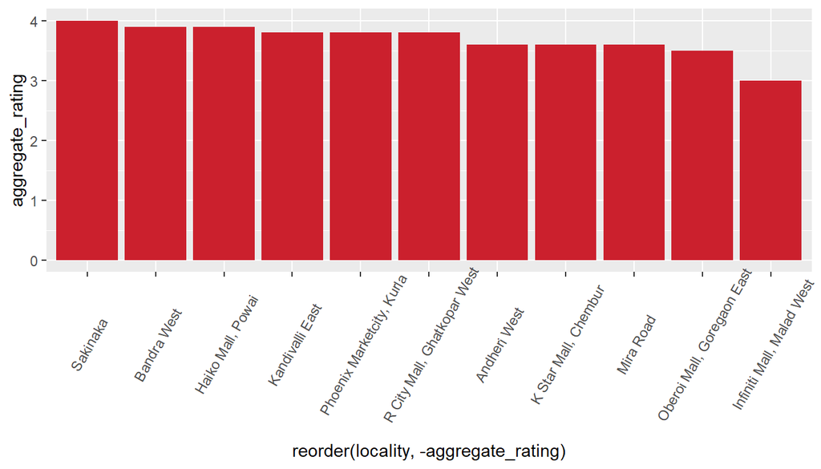

```r
c=df3%>%
  select(-delivery,-cuisines,-highlights)%>%
  filter(name=="KFC")

c=unique(c)
c=c[c(-12,-8)]

c[1,4]="Bandra West"
c[2,4]="Andheri West"
c[7,4]="Kandivalli East"

ggplot(c,aes(x=reorder(locality,-aggregate_rating),y=aggregate_rating))+geom_bar(stat='identity',fill='#cb202d')+theme(axis.text.x = element_text(angle = 60, vjust = .6))
```

#### **INFERENCE**:Quality of KFC is very good in Sakinaka locality.Followed by Bandra West,Powai and so on.

### Quality of Behrouz Biriyani in different localities of Mumbai based on aggregate ratings

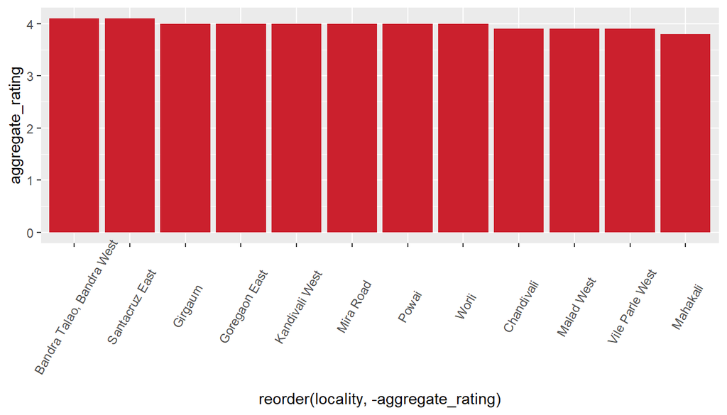

```r
c=df3%>%
  select(-delivery,-cuisines,-highlights)%>%
  filter(name=="Behrouz Biryani")

c=unique(c)


ggplot(c,aes(x=reorder(locality,-aggregate_rating),y=aggregate_rating))+geom_bar(stat='identity',fill='#cb202d')+theme(axis.text.x = element_text(angle = 60, vjust = .6))
```

#### **INFERENCE**:Quality of Behrouz Biriyani is very good in Bandra West locality.Followed by Santacruz,Girgaum and so on.

### **(v)Univariate Analysis on Mumbai:**

### Frequency distribution on average cost for two.

```r
res=suppressMessages(dcast(df3, cut2(df3$average_cost_for_two, g = 10)~.,value.var = "average_cost_for_two"))
names(res) <- c("cost_for_two_bin", "count")
res
```

```
##     cost_for_two_bin count
##  1:     [  50,  250)   291
##  2:     [ 250,  400)   266
##  3:              400   207
##  4:     [ 450,  600)   258
##  5:     [ 600,  750)   295
##  6:     [ 750, 1100)   255
##  7:     [1100, 1450)   236
##  8:     [1450, 1800)   217
##  9:     [1800, 2500)   265
## 10:     [2500,30000]   240
```

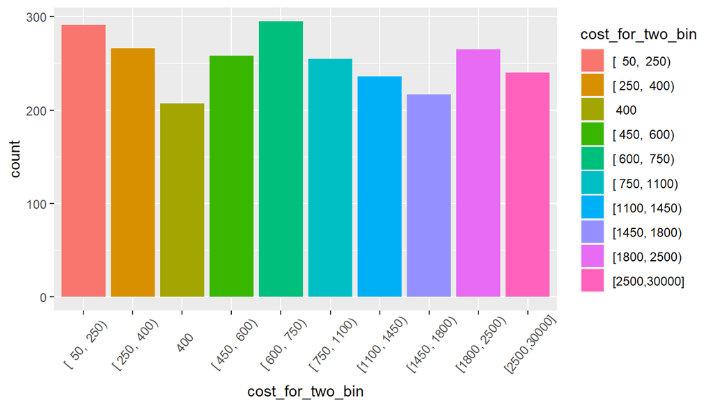

```r
ggplot(data=res,mapping=aes(x=cost_for_two_bin,y=count,fill=cost_for_two_bin))+geom_bar(stat = "identity")+theme(axis.text.x = element_text(angle = 50, vjust = .6))
```

### Top 5 cuisines in Mumbai

```r
p1=df3%>%
  select(cuisines)%>%
  unique()%>%
  mutate(cuisines=as.character(cuisines))%>%
  unnest_tokens(ngram,cuisines,token = 'ngrams',n=2)%>%
  group_by(ngram)%>%
  summarise(n=n())%>%
  arrange(desc(n))
p1[3,1]="chinese"
p=p1%>%
  top_n(5)
```

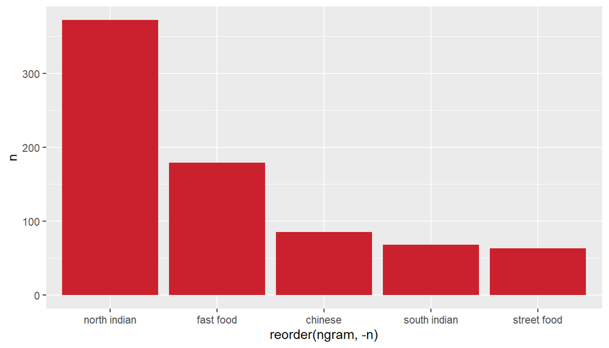

```r
ggplot(p,aes(x=reorder(ngram,-n),y=n))+geom_bar(stat='identity',fill='#cb202d')
```

#### **INFERENCE:** Majority of the restaurants have north Indian Cuisine followed by fast food,Chinese ,South Indian and Street food.

### Word Cloud on Cuisine types in mumbai

```r
wordcloud2(p1)
```

[interactive chart not shown]

### **(Vi) Bivariate Analysis on top Cities in India:**

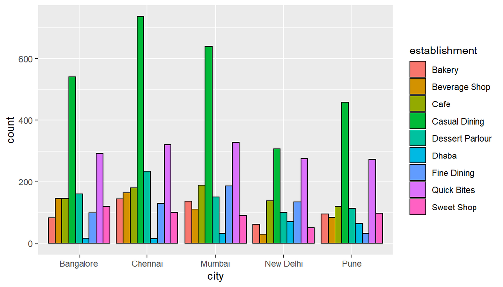

```r
df1=df%>%
  filter(city=="Chennai"|city=="Mumbai"|city=="Bangalore"|city=="Pune"|city=="New Delhi")

df1=df1%>%
  filter(establishment=="Casual Dining"|establishment=="Quick Bites"|establishment=="Cafe"|establishment=="Dessert Parlour"|establishment=="Bakery"|establishment=="Sweet Shop"|establishment=="Beverage Shop"|establishment=="Fine Dining"|establishment=="Dhaba")


bp=ggplot(data = df1) +
  geom_bar(mapping = aes(x = city, fill = establishment),colour="black", position = "dodge")

bp
```

#### **INFERENCE**:In all the top 5 cities,Casual dining restaurants are more in number followed by quick bites in the 2nd spot.Bangalore and chennai have Dessert Parlour restuarants in 3rd spot whereas Mumbai and New Delhi have Fine Dining in 3rd spot.Pune has Cafe restaurant in 3rd spot.

### Barplot on number of restaurants based on the top 10 cities and the delivery options.

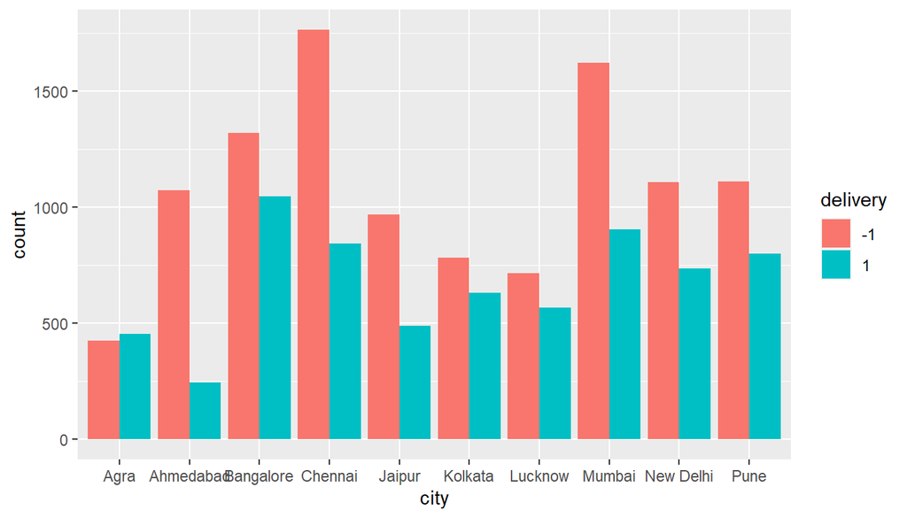

```r
df1=df%>%
  filter(city=="Agra" | city=="Chennai"|city=="Mumbai"| city=="Bangalore"| city=="Pune"|city=="New Delhi"|city=="Jaipur"|city=="Kolkata"|city=="Ahmedabad"|city=="Lucknow" )

df1$delivery=as.factor(df1$delivery)

ggplot(data = df1) +
  geom_bar(mapping = aes(x = city, fill = delivery), position = "dodge")
```

#### **INFERENCE:**Except Agra,All the other cities have less restaurants that deliver.In Agra the restaurants with delivery option is marginally high from non deliverable restaurants.

### Barplot on number of restaurants based on city and price_range

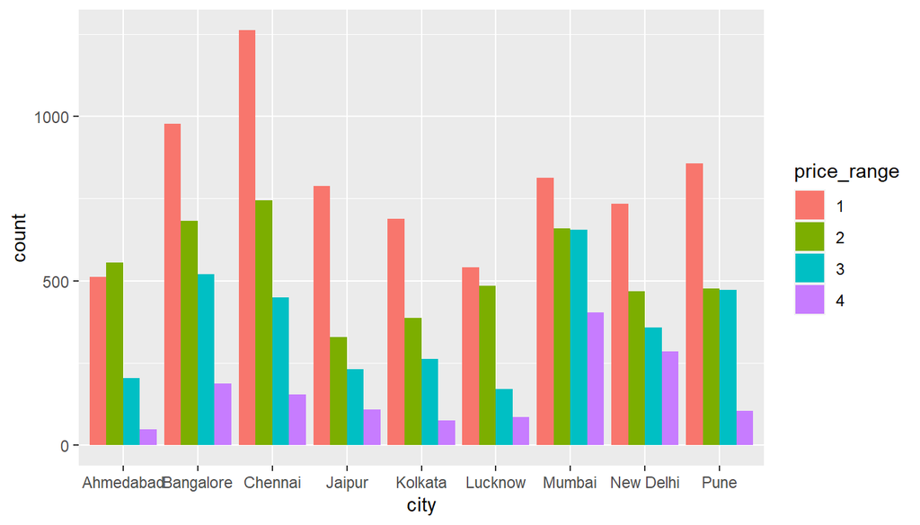

```r
df1=df%>%
  filter( city=="Chennai"|city=="Mumbai"| city=="Bangalore"| city=="Pune"|city=="New Delhi"|city=="Jaipur"|city=="Kolkata"|city=="Ahmedabad"|city=="Lucknow" )

df1$price_range=as.factor(df1$price_range)

ggplot(data = df1) +
  geom_bar(mapping = aes(x = city, fill = price_range), position = "dodge")
```

#### **INFERENCE**:All the cities except ahmedabad follows the pattern of having more number of restaurants in price range “1” followed “2”,“3”,“4”.In ahmedabad,restaurants with price range “2” is higher followed by “1”,“3” and “4”.

### Barplot on number of restaurants based on city and rating text

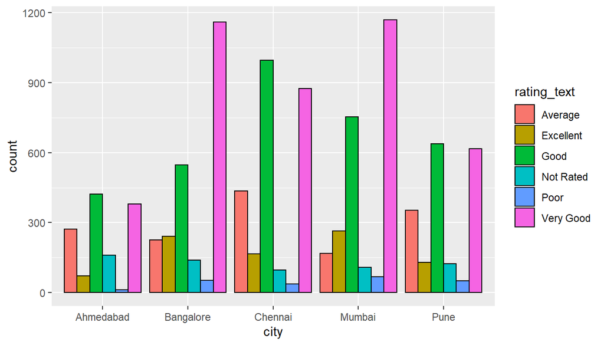

```r
df1=df%>%
  filter(city=="Chennai"|city=="Mumbai"| city=="Bangalore"| city=="Pune"|city=="Ahmedabad")


df1$rating_text=as.factor(df1$rating_text)

ggplot(data = df1) +
  geom_bar(mapping = aes(x = city, fill = rating_text),colour="black", position = "dodge")
```

#### **INFERENCE**:From the top 5 cities in India.Cities like Bangalore and Mumbai have restaurants with rating as “Very Good” in 1st place.Ahmedabad,Chennai and Pune have restaurants with rating as “Good” in 1st place.Ahmedabad,Chennai and Pune have restaurants with rating as “Very Good” in 2nd place.Bangalore and Mumbai have restaurants with rating as “Good” in 2nd place.Ahmedabad,Chennai and Pune have restaurants with rating as “Average” in 3rd place.Bangalore and Mumbai have restaurants with rating as “Excellent” in 3rd place.In all the cities restaurants with poor ratings are in less in number.

### Boxplot on aggregate ratings based on the top 5 cities

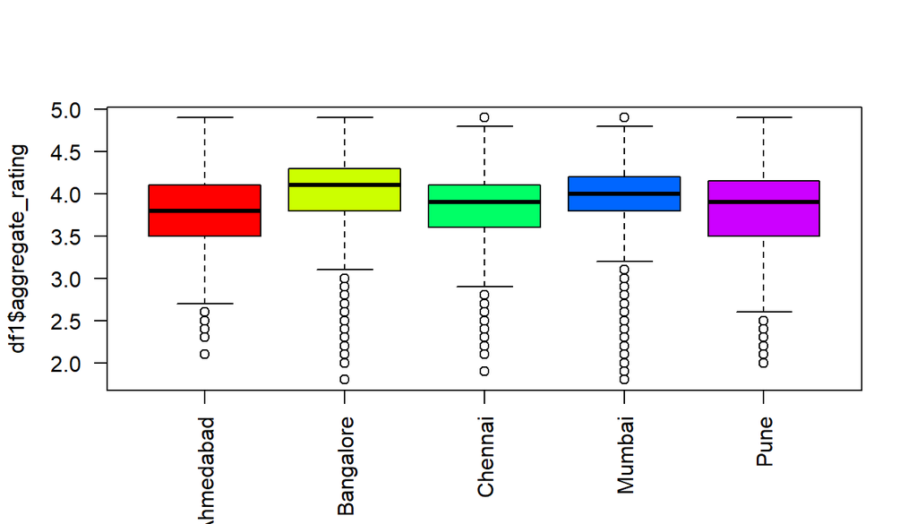

```r
df1$city=factor(df1$city)

df1=df1%>%
  filter(aggregate_rating!=0)

boxplot(df1$aggregate_rating~df1$city,las=2,xlab = "",col=rainbow(length(unique(df1$city))))
```

### Boxplot on average cost for two of the restaurants in top 9 cities

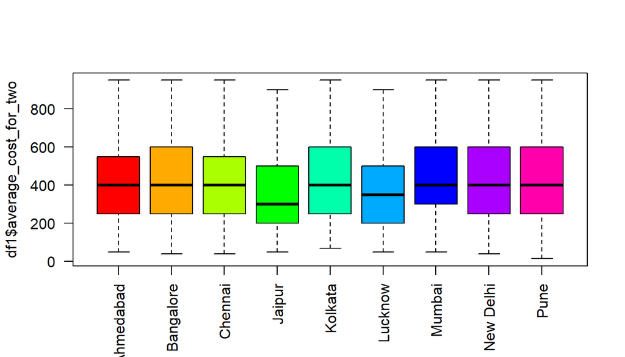

```r
df1=df%>%
  filter( city=="Chennai"|city=="Mumbai"| city=="Bangalore"| city=="Pune"|city=="New Delhi"|city=="Jaipur"|city=="Kolkata"|city=="Ahmedabad"|city=="Lucknow" )

df1$city=factor(df1$city)

df1=df1%>%
  filter(average_cost_for_two<1000)

boxplot(df1$average_cost_for_two~df1$city,las=2,xlab = "",col=rainbow(length(unique(df1$city))))
```

### Barplot on number of restaurants based on top 5 cities and top 6 cuisine type

```r
df1=df%>%
  filter( city=="Chennai"|city=="Mumbai"| city=="Bangalore"| city=="Pune"|city=="New Delhi")

p=df1%>%
  select(cuisines,city)%>%
  unique()%>%
  mutate(cuisines=as.character(cuisines))%>%
  unnest_tokens(ngram,cuisines,token = 'ngrams',n=2)%>%
  group_by(ngram,city)%>%
  summarise(n=n())%>%
  arrange(desc(n))
```

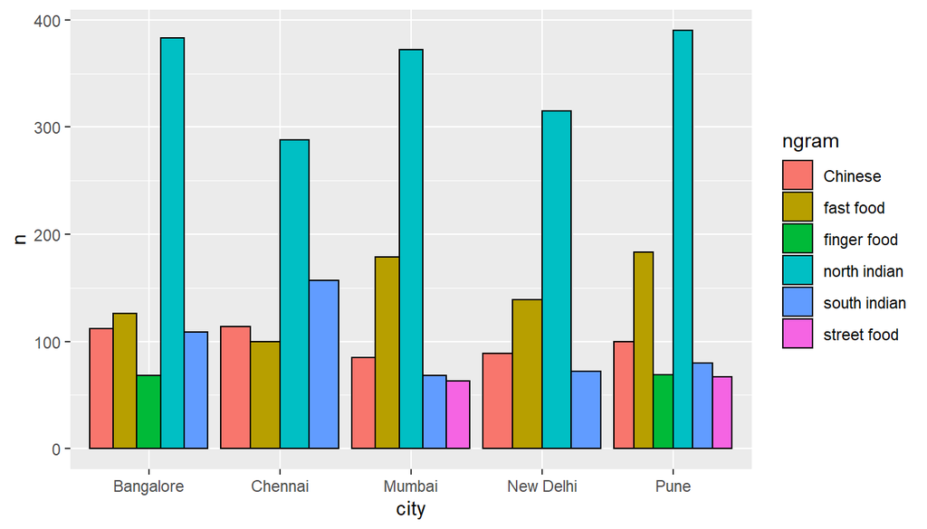

```r
w=head(p,n=24)




w=w%>%
  mutate(ngram=replace(ngram,ngram=="indian chinese","Chinese"))
ggplot(data = w) +
  geom_bar(mapping = aes(x = city,y=n, fill = ngram),colour="black",position = "dodge",stat = "identity")
```

#### **INFERENCE**:In all the cities Restaurants with North indian cuisine is present more.Bangalore,mumbai,New Delhi and Pune have fast food cuisine in 2nd place.Whereas Chennai has South indian cuisine restaurant in 2nd place.In 3rd place all the cities have Chinese cuisine.

## **INFERENTIAL STATISTICS :**

### correlation plot with average cost for 2 ,aggregate ratings,votes and photocount

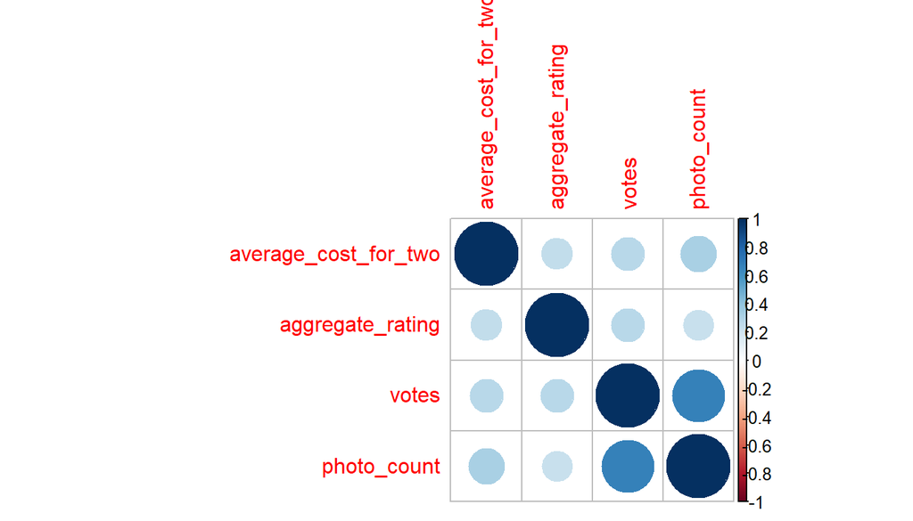

```r
M=cor(df[,c(7,10,12,13)])

corrplot(M)
```

#### **INFERENCE** Only Photo count and peoples votes is somewhat strongly correlated. From this we can infer that the restaurant which has more number of customers taking photos has higher number of people voting/liking the restaurant.This kind of relationship might be because of the promotion/offers these restaurants give to customers who vote and share photos with their friends.

### Correlation analysis using pearson method for photocount and votes of a restaurant

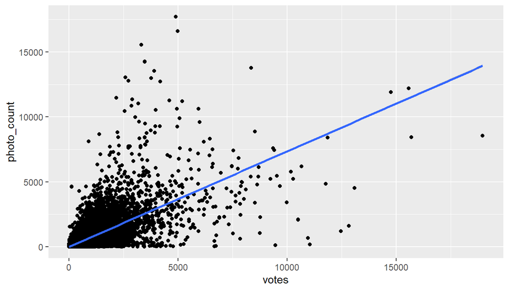

```r
df=df%>%
  filter(votes<20000)


ggplot(df,aes(x=votes,y=photo_count))+geom_point()+geom_smooth(method = "lm")
```

```r
cor.test(df$votes,df$photo_count,method = "pearson")
```

```
##
##  Pearson's product-moment correlation
##
## data:  df$votes and df$photo_count
## t = 249.06, df = 59550, p-value < 2.2e-16
## alternative hypothesis: true correlation is not equal to 0
## 95 percent confidence interval:
##  0.7103211 0.7181892
## sample estimates:
##       cor
## 0.7142777
```

### ONE WAY ANOVA TEST-To check if there is a significant difference in the average cost for two based on rating text

```r
#DF1-RESTAURANTS IN TOP 5 CITIES

df1=df1%>%
  filter(average_cost_for_two<3500)



df1$rating_text=as.factor(df1$rating_text)
levels(df1$rating_text)
```

```
## [1] "Average"   "Excellent" "Good"      "Not Rated" "Poor"      "Very Good"
```

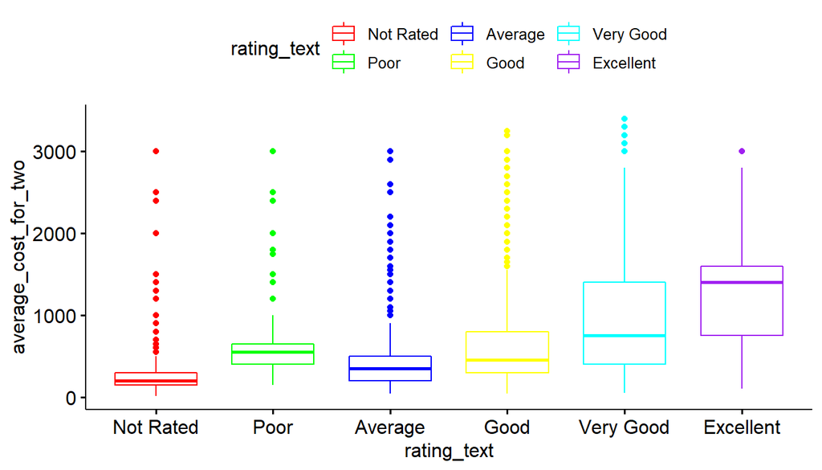

```r
#if not ordered, it can be reordered as follows
df1$rating_text <- ordered(df1$rating_text,levels=c("Not Rated","Poor","Average","Good","Very Good","Excellent"))


#visualize the data
library(ggplot2)



library(ggpubr)
ggboxplot(df1,x="rating_text",y="average_cost_for_two",color="rating_text",palette = c("red","green","blue","yellow","cyan","purple"))
```

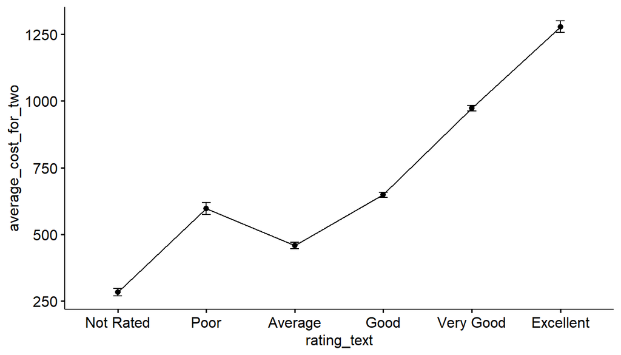

```r
#mean plots
#plot weight by group
#add error bars: mean_seW

ggline(df1,x="rating_text",y="average_cost_for_two",add = c("mean_se"))
```

```r
res <- aov(average_cost_for_two~rating_text,data=df1)
summary(res)
```

```
##                Df    Sum Sq   Mean Sq F value Pr(>F)
## rating_text     5 7.342e+08 146835697   397.5 <2e-16 ***
## Residuals   10996 4.061e+09    369353
## ---
## Signif. codes:  0 '***' 0.001 '**' 0.01 '*' 0.05 '.' 0.1 ' ' 1
```

```r
TukeyHSD(res)
```

```
##   Tukey multiple comparisons of means
##     95% family-wise confidence level
##
## Fit: aov(formula = average_cost_for_two ~ rating_text, data = df1)
##
## $rating_text
##                          diff        lwr        upr     p adj
## Poor-Not Rated       314.0004  183.04044  444.96043 0.0000000
## Average-Not Rated    174.6394   86.40532  262.87339 0.0000003
## Good-Not Rated       364.6300  284.95168  444.30839 0.0000000
## Very Good-Not Rated  689.9010  611.56836  768.23358 0.0000000
## Excellent-Not Rated  994.6188  901.14788 1088.08966 0.0000000
## Average-Poor        -139.3611 -257.61926  -21.10289 0.0102006
## Good-Poor             50.6296  -61.39001  162.64921 0.7916706
## Very Good-Poor       375.9005  264.83411  486.96696 0.0000000
## Excellent-Poor       680.6183  558.40312  802.83356 0.0000000
## Good-Average         189.9907  133.57155  246.40981 0.0000000
## Very Good-Average    515.2616  460.75954  569.76368 0.0000000
## Excellent-Average    819.9794  745.33837  894.62046 0.0000000
## Very Good-Good       325.2709  286.10627  364.43560 0.0000000
## Excellent-Good       629.9887  565.68726  694.29022 0.0000000
## Excellent-Very Good  304.7178  242.09162  367.34398 0.0000000
```

#### **INFERENCE**:Since the p value of anova test is less than 0.05 there is a significant difference in average cost for two based on rating text.From the tukeyHSD Test the only difference between Good and poor ratings is not significant with an adjusted p-value greater than 0.05.

## **PREDICTIVE STATISTICS**:

### Regression analysis-Predicting the restaurant’s average cost for 2 based on the various factors using multiple regression model.

```r
library(ggplot2)



df1=df1%>%
  select(-name,-locality,-cuisines,-timings,-highlights)


set.seed(123)
library(caret)
train_samples <- df1$average_cost_for_two %>%
  createDataPartition(p=0.8,list=FALSE)

#head(train_samples)
train <- df1[train_samples,]
test <- df1[-train_samples,]

#Building a multiple regression model

model <- lm(average_cost_for_two~.,data=train)


summary(model)
```

```
##
## Call:
## lm(formula = average_cost_for_two ~ ., data = train)
##
## Residuals:
##     Min      1Q  Median      3Q     Max
## -698.30 -100.09   -7.45   97.93  961.52
##
## Coefficients:
##                                Estimate Std. Error t value Pr(>|t|)
## (Intercept)                   2.602e+02  3.688e+01   7.055 1.86e-12 ***
## establishmentBar              1.994e+02  1.388e+01  14.365  < 2e-16 ***
## establishmentBeverage Shop   -1.949e+01  1.201e+01  -1.623 0.104681
## establishmentBhojanalya      -1.868e+01  2.799e+01  -0.667 0.504605
## establishmentButcher Shop     3.490e+01  2.496e+01   1.398 0.162111
## establishmentCafe             4.221e+01  1.177e+01   3.586 0.000337 ***
## establishmentCasual Dining    1.157e+02  1.061e+01  10.903  < 2e-16 ***
## establishmentClub             4.503e+02  3.717e+01  12.113  < 2e-16 ***
## establishmentCocktail Bar     5.250e+02  7.908e+01   6.638 3.36e-11 ***
## establishmentConfectionery   -3.772e+01  2.253e+01  -1.675 0.094066 .
## establishmentDessert Parlour -2.712e+01  1.122e+01  -2.418 0.015621 *
## establishmentDhaba            1.060e+01  1.635e+01   0.648 0.516964
## establishmentFine Dining      5.131e+02  1.657e+01  30.962  < 2e-16 ***
## establishmentFood Court       3.971e+01  1.378e+01   2.882 0.003965 **
## establishmentFood Truck      -6.644e+00  1.578e+01  -0.421 0.673632
## establishmentIrani Cafe      -1.976e+01  6.219e+01  -0.318 0.750675
## establishmentKiosk           -6.102e+01  1.340e+01  -4.553 5.35e-06 ***
## establishmentLounge           2.606e+02  1.513e+01  17.223  < 2e-16 ***
## establishmentMess            -1.325e+01  1.570e+01  -0.844 0.398953
## establishmentMicrobrewery     2.426e+02  2.989e+01   8.117 5.43e-16 ***
## establishmentNot Mentioned   -6.994e+00  1.330e+01  -0.526 0.598926
## establishmentPaan Shop       -1.639e+02  2.173e+01  -7.543 5.06e-14 ***
## establishmentPub              2.180e+02  1.790e+01  12.180  < 2e-16 ***
## establishmentQuick Bites     -4.199e+01  9.968e+00  -4.212 2.55e-05 ***
## establishmentShack            1.276e+02  1.744e+02   0.732 0.464361
## establishmentSweet Shop      -4.368e+01  1.248e+01  -3.500 0.000468 ***
## cityChennai                   2.005e+00  5.751e+00   0.349 0.727346
## cityMumbai                    3.665e+01  5.900e+00   6.212 5.46e-10 ***
## cityNew Delhi                 3.008e+01  6.531e+00   4.606 4.17e-06 ***
## cityPune                      4.702e+00  6.244e+00   0.753 0.451452
## price_range2                  2.893e+02  5.825e+00  49.670  < 2e-16 ***
## price_range3                  8.972e+02  8.438e+00 106.334  < 2e-16 ***
## price_range4                  1.755e+03  1.167e+01 150.364  < 2e-16 ***
## aggregate_rating              8.231e+00  1.192e+01   0.690 0.489918
## rating_text.L                 3.775e+01  4.219e+01   0.895 0.370925
## rating_text.Q                 1.394e+01  1.599e+01   0.872 0.383492
## rating_text.C                 1.528e+01  1.046e+01   1.461 0.143917
## rating_text^4                -1.748e+01  8.677e+00  -2.015 0.043964 *
## rating_text^5                 7.567e+00  6.123e+00   1.236 0.216577
## votes                        -2.162e-03  2.310e-03  -0.936 0.349319
## photo_count                   4.223e-03  2.172e-03   1.944 0.051954 .
## delivery1                     1.046e+01  4.050e+00   2.584 0.009783 **
## ---
## Signif. codes:  0 '***' 0.001 '**' 0.01 '*' 0.05 '.' 0.1 ' ' 1
##
## Residual standard error: 173.8 on 8761 degrees of freedom
## Multiple R-squared:  0.931,  Adjusted R-squared:  0.9307
## F-statistic:  2883 on 41 and 8761 DF,  p-value: < 2.2e-16
```

```r
#Make predictions
pred <- model %>%
  predict(test)



R2 <- R2(pred,test$average_cost_for_two)
R2 #should be greater
```

```
## [1] 0.9335609
```

#### **INFERENCE**:The prediction model gives an R2 score of 0.93